# jpmesh: Utilities for Japanese Mesh Code

Shinya Uryu

2018/3/8

# jpmesh

## jpmesh

The **jpmesh** is a package that makes it easy to use “regional mesh (i.e. mesh code *JIS X 0410* )” used in Japan from R. Regional mesh is a code given when subdividing Japanese landscape into rectangular subregions by latitude and longitude. Depending on the accuracy of the code, different regional mesh length. By using the same mesh in statistical survey etc., it will become possible to handle the survey results of a large area in the area mesh unit.

## jpmesh

In jpmesh, mesh codes and latitude and longitude coordinates are compatible with mesh codes from the first region mesh, which is the standard region mesh, to the quarter regional mesh of the divided region mesh (from 80 km to 125 m). Features include “conversion from latitude and longitude to regional mesh”, “acquisition of latitude and longitude from regional mesh”, “mapping on prefecture unit and leaflet”.

# Usage

## Install

Available CRAN (`version 1.1.0`), and olso GitHub develop versions.

```r
# CRAN
install.packages("jpmesh")
```

```r
# the development version from GitHub:
install.packages("remotes")
remotes::install_github("uribo/jpmesh")
```

```r
library(jpmesh)
library(sf)
library(leaflet)
```

## Convert mesh code to coordinate and vice versa

Return the *latitude* and *longitude* for specifying the mesh range from the mesh code.

```r
mesh_to_coords(5133) # 80km
```

```
## # A tibble: 1 x 4
##   lng_center lat_center lng_error lat_error
##        <dbl>      <dbl>     <dbl>     <dbl>
## 1       134.       34.3     0.500     0.333
```

```r
mesh_to_coords(513377) # 10km
# ...
mesh_to_coords(51337783123) # 125m
```

## Convert mesh code to coordinate and vice versa

Find the mesh code within the range from *latitude* and *longitude*.

```r
coords_to_mesh(133, 34) # default as 1km meshcode
```

```
## [1] "51330000"
```

```r
coords_to_mesh(133, 34, mesh_size = "80km")
```

```
## [1] "5133"
```

```r
coords_to_mesh(133, 34, mesh_size = "125m")
```

```
## [1] "51330000111"
```

## Detect fine and neighborhood mesh codes

```r
mesh_80km <- coords_to_mesh(133, 34, "80km")
# Convert to sfc_POLYGON
mesh_polygon <- mesh_80km %>%
  export_mesh()

mesh_polygon
```

```
## Geometry set for 1 feature
## geometry type:  POLYGON
## dimension:      XY
## bbox:           xmin: 133 ymin: 34 xmax: 134 ymax: 34.66667
## epsg (SRID):    4326
## proj4string:    +proj=longlat +datum=WGS84 +no_defs
```

```
## POLYGON ((133 34, 134 34, 134 34.66667, 133 34....
```

## Detect fine and neighborhood mesh codes

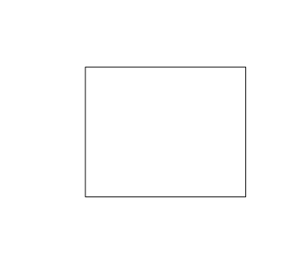

```r
mesh_polygon %>%
  st_geometry() %>%
  plot()
```

## Detect fine and neighborhood mesh codes

```r
# Returns a finer mesh of the area of the mesh codes
# Such as, 80km to 10km mesh codes.
meshes_10km <- mesh_80km %>%
  fine_separate()

meshes_10km
```

```
##  [1] "513300" "513301" "513302" "513303" "513304" "513305" "513306"
##  [8] "513307" "513310" "513311" "513312" "513313" "513314" "513315"
## [15] "513316" "513317" "513320" "513321" "513322" "513323" "513324"
## [22] "513325" "513326" "513327" "513330" "513331" "513332" "513333"
## [29] "513334" "513335" "513336" "513337" "513340" "513341" "513342"
## [36] "513343" "513344" "513345" "513346" "513347" "513350" "513351"
## [43] "513352" "513353" "513354" "513355" "513356" "513357" "513360"
## [50] "513361" "513362" "513363" "513364" "513365" "513366" "513367"
## [57] "513370" "513371" "513372" "513373" "513374" "513375" "513376"
## [64] "513377"
```

## Detect fine and neighborhood mesh codes

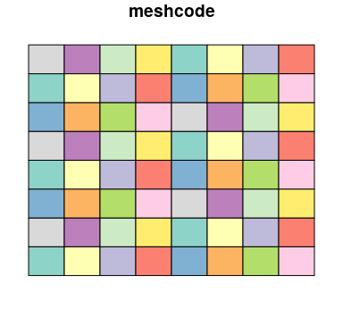

```r
meshes_10km %>%
  export_meshes() %>%
  plot()
```

## Detect fine and neighborhood mesh codes

```r
# the value of the adjacent mesh codes
coords_to_mesh(133, 34, "80km") %>%
  neighbor_mesh()
```

```
## [1] "5032" "5033" "5034" "5132" "5133" "5134" "5232" "5233" "5234"
```

```r
coords_to_mesh(133, 34, "500m") %>%
  neighbor_mesh()
```

[output not shown]

## Detect fine and neighborhood mesh codes

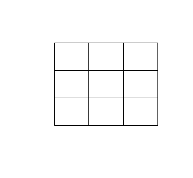

1km neighborhood meshes

```r
mesh_1km_neighbors <- coords_to_mesh(133, 34, "1km") %>%
  neighbor_mesh()
mesh_1km_neighbors %>%
  export_meshes() %>%
  st_geometry() %>%
  plot()
```

# Plots and Visualize

## ggplot2

```r
remotes::install_github("hadley/ggplot2")

library(ggplot2)
```

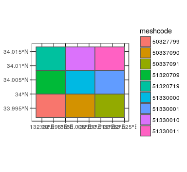

```r
ggplot() +
  geom_sf(data = mesh_1km_neighbors %>%
  export_meshes(), aes(fill = meshcode)) +
  theme_bw()
```

## Administration mesh

```r
set.seed(71)
# Select prefecture or city code
administration_mesh(code = 33, type = "prefecture") %>%
  sample(5)
```

[output not shown]

## Mapping on Leaflet

```r
leaflet() %>%
  addTiles() %>%
  addProviderTiles("OpenStreetMap.BlackAndWhite") %>%
  addPolygons(data = administration_mesh(code = 33101, type = "city"))
```

[interactive chart not shown]